# Lake Okeechobee WBID Evaluation

Updated: March 09, 2023

### [Source Code](https://github.com/owper-tech/LakeO_WQ)

- GitHub repo https://github.com/owper-tech/LakeO_WQ

### Study Area

[interactive chart not shown]

Figure 1. Lake Okeechobee Water Body IDs (WBIDs) and monitoring locations sampled by the South Florida Water Management District.

### Data

Alkalinity, Color, Chlorophyll-a, Total Phosphorus and Total Nitrogen (direct measure or calculated NO<sub>x</sub> + TKN) data data were retrieved from the South Florida Water Management District online environmental database ([DBHYDRO](https://www.sfwmd.gov/dbhydro)) from monitoring locations (Fig 1) between May 1, 2000 and April 30, 2022. Data reported less than the minimum detection limit (MDL) where set to one-half the MDL. Annual geometric mean concentrations for all parameters and stations were calculated for stations and parameters with greater than or equal to four samples per water year and atleast one sample in the wet (May - October) and Dry (November - April). Annual geometric mean concentrations were averaged across water body identification (WBID) segments and evaluated relative to the numeric interpretations of narrative nutrient criteria presented below. For purposes of this analysis long-term is identified as a 3-year period.

#### 62-302.531 FAC Numeric Interpretations of Narrative Nutrient Criteria.

Full details associated with the Numeric Interpretation of Narrative Nutrient Criteria can be found [here](https://www.flrules.org/gateway/ruleno.asp?id=62-302.531).

**62-302.531(2)(b)1 FAC**

For lakes, the applicable numeric interpretations of the narrative nutrient criterion in paragraph 62-302.530(47)(b), F.A.C., for chlorophyll a are shown in the table below. The applicable interpretations for TN and TP will vary on an annual basis, depending on the availability of chlorophyll a data and the concentrations of nutrients and chlorophyll a in the lake, as described below. The applicable numeric interpretations for TN, TP, and chlorophyll a shall not be exceeded more than once in any consecutive three year period.

62-302.531(2)(b)1b FAC. Lake-Specific Numeric Interpretations of the Narrative Nutrient Criterion.

| Long Term Geometric Mean Lake Color and Alkalinity | Annual Geometric Mean Chlorophyll-a (μg L⁻¹) | Minimum calculated numeric interpretation Annual Geometric Mean Total Phosphorus (mg L⁻¹) | Minimum calculated numeric interpretation Annual Geometric Mean Total Nitrogen (mg L⁻¹) | Maximum calculated numeric interpretation Annual Geometric Mean Total Phosphorus (mg L⁻¹) | Maximum calculated numeric interpretation Annual Geometric Mean Total Nitrogen (mg L⁻¹) |
| --- | --- | --- | --- | --- | --- |
| ≥ 40 Platinum Cobalt Units | 20 | 0.05 | 1.27 | 0.16 | 2.23 |
| ≤ 40 Platinum Cobalt Units and ≥ 20 mg/L CaCO₃ | 20 | 0.03 | 1.05 | 0.09 | 1.91 |
| ≤ 40 Platinum Cobalt Units and ≤ 20 mg/L CaCO₃ | 6 | 0.01 | 0.51 | 0.03 | 0.93 |

### Water Quality Evaluation

##### 3212A

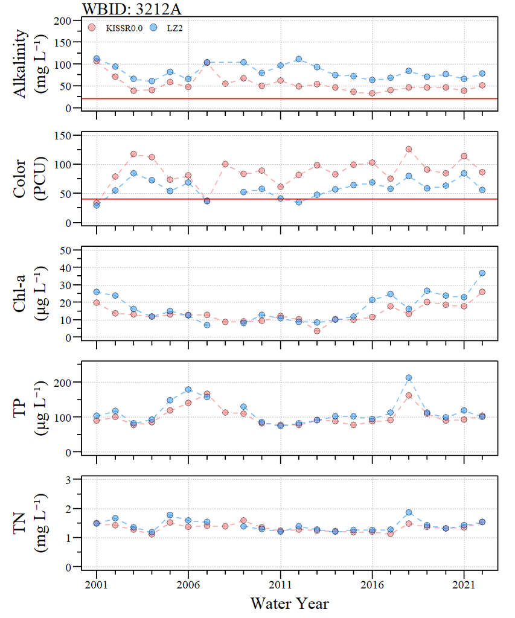

Annual Geometric Mean concentration for Alkalinity, Color, Chlorophyll, Total Phosphorus and Total Nitrogen .

Average annual geometric mean concentration across WBID3212A with annual exceedances identified by shaded area on the table.

| WBID | WY | Alkalinity (mg L⁻¹) | Color (PCU) | Chlorophyll-a (μg L⁻¹) | Total Phosphorus (mg L⁻¹) | Total Nitrogen (mg L⁻¹) |
| --- | --- | --- | --- | --- | --- | --- |
| 3212A | 2001 | 110 | 32 | 23 | 0.10 | 1.49 |
| 3212A | 2002 | 82 | 67 | 19 | 0.11 | 1.54 |
| 3212A | 2003 | 52 | 101 | 14 | 0.08 | 1.32 |
| 3212A | 2004 | 51 | 92 | 12 | 0.09 | 1.15 |
| 3212A | 2005 | 70 | 64 | 14 | 0.13 | 1.64 |
| 3212A | 2006 | 56 | 75 | 12 | 0.16 | 1.48 |
| 3212A | 2007 | 103 | 37 | 10 | 0.16 | 1.47 |
| 3212A | 2008 | 55 | 100 | 9 | 0.11 | 1.39 |
| 3212A | 2009 | 85 | 68 | 9 | 0.12 | 1.49 |
| 3212A | 2010 | 65 | 73 | 11 | 0.08 | 1.32 |
| 3212A | 2011 | 79 | 51 | 12 | 0.08 | 1.22 |
| 3212A | 2012 | 80 | 58 | 10 | 0.08 | 1.33 |
| 3212A | 2013 | 73 | 73 | 6 | 0.09 | 1.26 |
| 3212A | 2014 | 60 | 70 | 10 | 0.10 | 1.21 |
| 3212A | 2015 | 54 | 82 | 11 | 0.09 | 1.22 |
| 3212A | 2016 | 48 | 85 | 16 | 0.09 | 1.22 |
| 3212A | 2017 | 54 | 67 | 21 | 0.10 | 1.20 |
| 3212A | 2018 | 65 | 102 | 15 | 0.19 | 1.67 |
| 3212A | 2019 | 58 | 75 | 23 | 0.11 | 1.40 |
| 3212A | 2020 | 62 | 74 | 21 | 0.09 | 1.32 |
| 3212A | 2021 | 52 | 99 | 20 | 0.11 | 1.39 |
| 3212A | 2022 | 64 | 71 | 31 | 0.10 | 1.53 |

Includes Stations: KISSR0.0, LZ2

##### 3212B

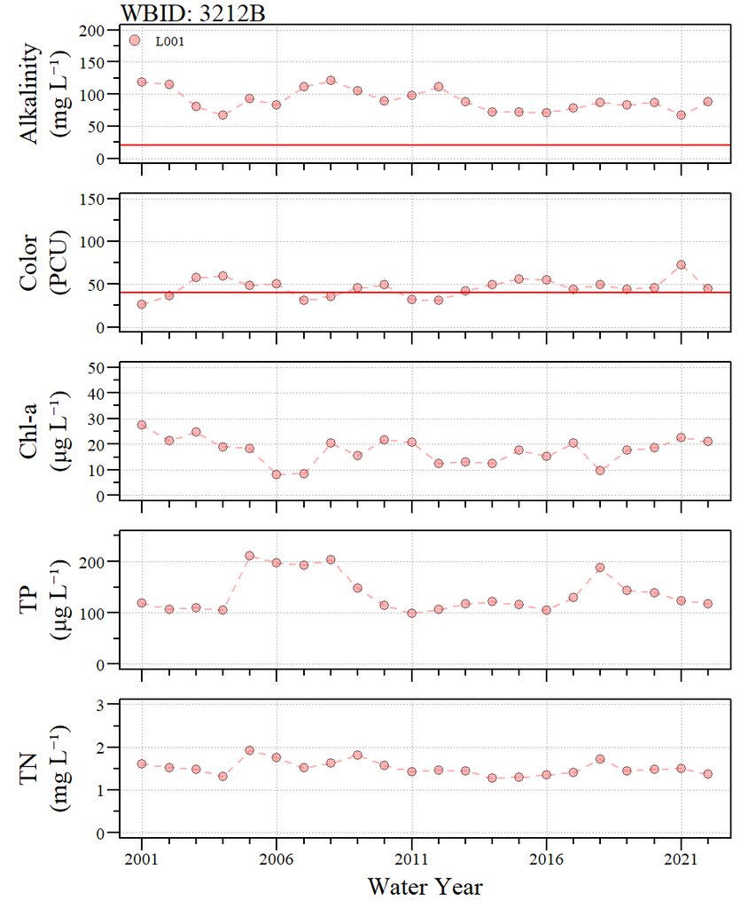

Annual Geometric Mean concentration for Alkalinity, Color, Chlorophyll, Total Phosphorus and Total Nitrogen .

Average annual geometric mean concentration across WBID3212B with annual exceedances identified by shaded area on the table.

| WBID | WY | Alkalinity (mg L⁻¹) | Color (PCU) | Chlorophyll-a (μg L⁻¹) | Total Phosphorus (mg L⁻¹) | Total Nitrogen (mg L⁻¹) |
| --- | --- | --- | --- | --- | --- | --- |
| 3212B | 2001 | 119 | 26 | 27 | 0.12 | 1.61 |
| 3212B | 2002 | 115 | 36 | 21 | 0.11 | 1.52 |
| 3212B | 2003 | 81 | 57 | 25 | 0.11 | 1.47 |
| 3212B | 2004 | 67 | 60 | 19 | 0.10 | 1.31 |
| 3212B | 2005 | 92 | 48 | 18 | 0.21 | 1.92 |
| 3212B | 2006 | 83 | 51 | 8 | 0.20 | 1.75 |
| 3212B | 2007 | 111 | 31 | 8 | 0.19 | 1.51 |
| 3212B | 2008 | 122 | 36 | 20 | 0.20 | 1.62 |
| 3212B | 2009 | 105 | 46 | 16 | 0.15 | 1.82 |
| 3212B | 2010 | 90 | 49 | 22 | 0.11 | 1.57 |
| 3212B | 2011 | 98 | 32 | 21 | 0.10 | 1.42 |
| 3212B | 2012 | 111 | 31 | 12 | 0.11 | 1.46 |
| 3212B | 2013 | 88 | 42 | 13 | 0.12 | 1.44 |
| 3212B | 2014 | 72 | 49 | 12 | 0.12 | 1.27 |
| 3212B | 2015 | 72 | 56 | 17 | 0.12 | 1.29 |
| 3212B | 2016 | 71 | 55 | 15 | 0.10 | 1.34 |
| 3212B | 2017 | 78 | 43 | 20 | 0.13 | 1.40 |
| 3212B | 2018 | 86 | 49 | 10 | 0.19 | 1.71 |
| 3212B | 2019 | 84 | 44 | 18 | 0.14 | 1.43 |
| 3212B | 2020 | 87 | 46 | 19 | 0.14 | 1.48 |
| 3212B | 2021 | 67 | 73 | 22 | 0.12 | 1.49 |
| 3212B | 2022 | 87 | 45 | 21 | 0.12 | 1.36 |

Includes Stations: L001

##### 3212C

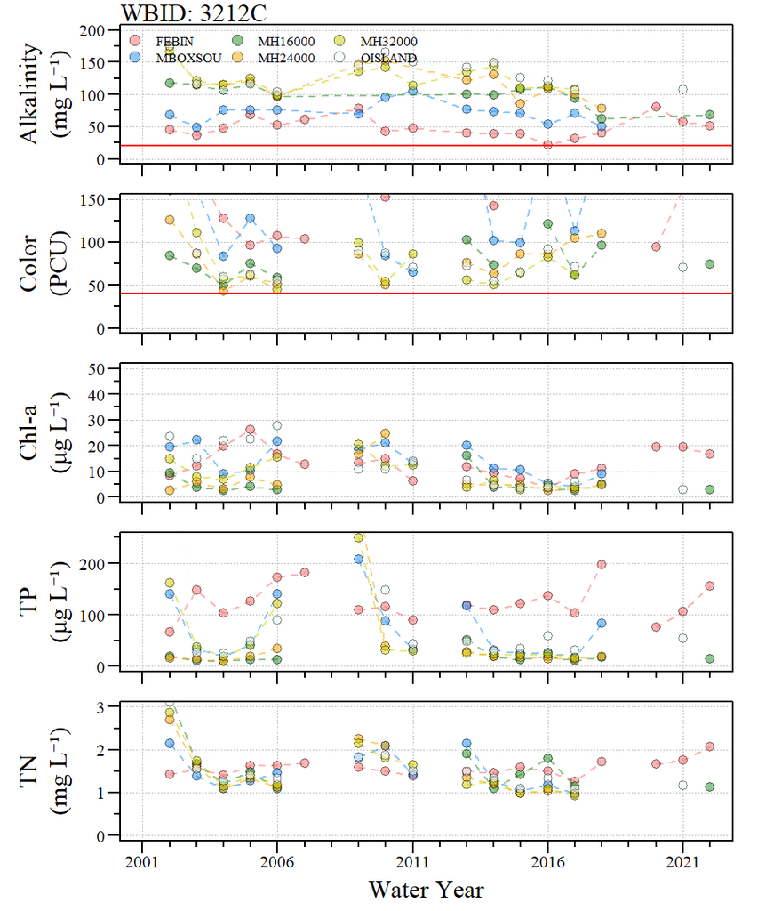

Annual Geometric Mean concentration for Alkalinity, Color, Chlorophyll, Total Phosphorus and Total Nitrogen .

Average annual geometric mean concentration across WBID3212C with annual exceedances identified by shaded area on the table.

| WBID | WY | Alkalinity (mg L⁻¹) | Color (PCU) | Chlorophyll-a (μg L⁻¹) | Total Phosphorus (mg L⁻¹) | Total Nitrogen (mg L⁻¹) |
| --- | --- | --- | --- | --- | --- | --- |
| 3212C | 2001 |  |  |  |  |  |
| 3212C | 2002 | 124 | 184 | 13 | 0.14 | 2.58 |
| 3212C | 2003 | 92 | 116 | 11 | 0.05 | 1.58 |
| 3212C | 2004 | 94 | 70 | 11 | 0.03 | 1.21 |
| 3212C | 2005 | 104 | 80 | 14 | 0.05 | 1.42 |
| 3212C | 2006 | 88 | 68 | 15 | 0.10 | 1.30 |
| 3212C | 2007 | 61 | 103 | 13 | 0.18 | 1.68 |
| 3212C | 2008 |  |  |  |  |  |
| 3212C | 2009 | 115 | 126 | 16 | 0.24 | 1.92 |
| 3212C | 2010 | 119 | 86 | 17 | 0.08 | 1.87 |
| 3212C | 2011 | 104 | 96 | 12 | 0.05 | 1.49 |
| 3212C | 2012 |  |  |  |  |  |
| 3212C | 2013 | 103 | 125 | 11 | 0.06 | 1.59 |
| 3212C | 2014 | 106 | 81 | 7 | 0.04 | 1.27 |
| 3212C | 2015 | 90 | 105 | 5 | 0.04 | 1.19 |
| 3212C | 2016 | 88 | 144 | 4 | 0.05 | 1.32 |
| 3212C | 2017 | 85 | 100 | 5 | 0.03 | 1.06 |
| 3212C | 2018 | 58 | 157 | 8 | 0.08 | 1.72 |
| 3212C | 2019 |  |  |  |  |  |
| 3212C | 2020 | 80 | 94 | 19 | 0.08 | 1.66 |
| 3212C | 2021 | 82 | 116 | 11 | 0.08 | 1.46 |
| 3212C | 2022 | 60 | 129 | 10 | 0.09 | 1.60 |

Includes Stations: FEBIN, MBOXSOU, MH16000, MH24000, MH32000, OISLAND

##### 3212D

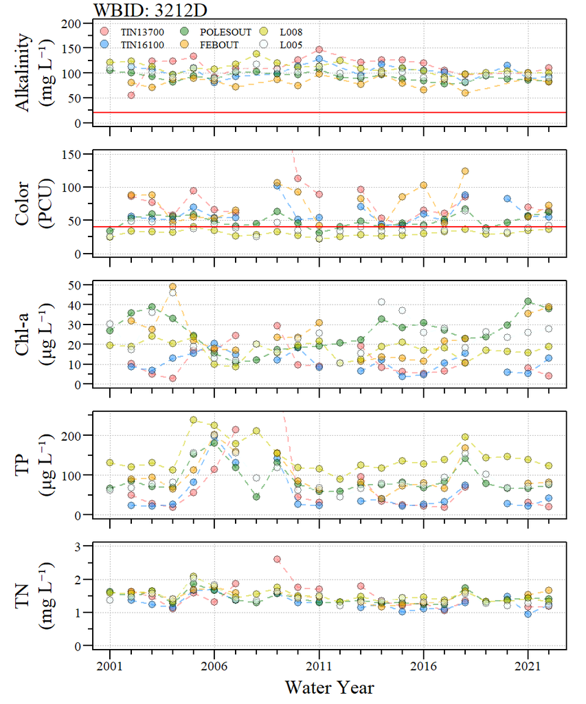

Annual Geometric Mean concentration for Alkalinity, Color, Chlorophyll, Total Phosphorus and Total Nitrogen .

Average annual geometric mean concentration across WBID3212D with annual exceedances identified by shaded area on the table.

| WBID | WY | Alkalinity (mg L⁻¹) | Color (PCU) | Chlorophyll-a (μg L⁻¹) | Total Phosphorus (mg L⁻¹) | Total Nitrogen (mg L⁻¹) |
| --- | --- | --- | --- | --- | --- | --- |
| 3212D | 2001 | 112 | 28 | 26 | 0.09 | 1.53 |
| 3212D | 2002 | 97 | 61 | 20 | 0.07 | 1.52 |
| 3212D | 2003 | 102 | 59 | 23 | 0.07 | 1.52 |
| 3212D | 2004 | 96 | 47 | 27 | 0.06 | 1.28 |
| 3212D | 2005 | 108 | 59 | 20 | 0.13 | 1.82 |
| 3212D | 2006 | 90 | 50 | 16 | 0.19 | 1.68 |
| 3212D | 2007 | 99 | 48 | 15 | 0.16 | 1.51 |
| 3212D | 2008 | 120 | 33 | 17 | 0.12 | 1.40 |
| 3212D | 2009 | 103 | 102 | 19 | 0.17 | 1.79 |
| 3212D | 2010 | 104 | 61 | 19 | 0.07 | 1.48 |
| 3212D | 2011 | 117 | 43 | 19 | 0.06 | 1.46 |
| 3212D | 2012 | 105 | 33 | 14 | 0.06 | 1.28 |
| 3212D | 2013 | 97 | 61 | 15 | 0.08 | 1.40 |
| 3212D | 2014 | 107 | 40 | 21 | 0.06 | 1.29 |
| 3212D | 2015 | 102 | 46 | 18 | 0.07 | 1.27 |
| 3212D | 2016 | 95 | 57 | 16 | 0.07 | 1.28 |
| 3212D | 2017 | 92 | 46 | 19 | 0.07 | 1.23 |
| 3212D | 2018 | 83 | 77 | 17 | 0.13 | 1.53 |
| 3212D | 2019 | 97 | 34 | 22 | 0.11 | 1.30 |
| 3212D | 2020 | 101 | 48 | 19 | 0.08 | 1.35 |
| 3212D | 2021 | 94 | 51 | 22 | 0.07 | 1.30 |
| 3212D | 2022 | 93 | 55 | 23 | 0.07 | 1.34 |

Includes Stations: TIN13700, TIN16100, POLESOUT, FEBOUT, L008, L005

##### 3212E

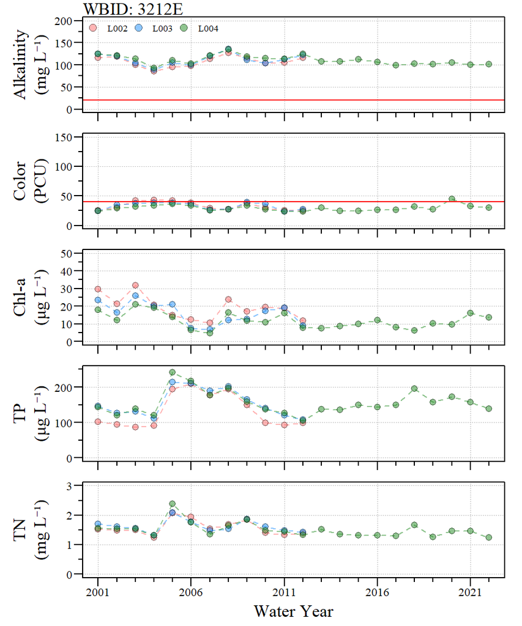

Annual Geometric Mean concentration for Alkalinity, Color, Chlorophyll, Total Phosphorus and Total Nitrogen .

Average annual geometric mean concentration across WBID3212E with annual exceedances identified by shaded area on the table.

| WBID | WY | Alkalinity (mg L⁻¹) | Color (PCU) | Chlorophyll-a (μg L⁻¹) | Total Phosphorus (mg L⁻¹) | Total Nitrogen (mg L⁻¹) |
| --- | --- | --- | --- | --- | --- | --- |
| 3212E | 2001 | 122 | 25 | 24 | 0.13 | 1.59 |
| 3212E | 2002 | 120 | 32 | 17 | 0.11 | 1.54 |
| 3212E | 2003 | 106 | 37 | 26 | 0.12 | 1.53 |
| 3212E | 2004 | 89 | 38 | 20 | 0.11 | 1.28 |
| 3212E | 2005 | 104 | 39 | 17 | 0.22 | 2.18 |
| 3212E | 2006 | 100 | 36 | 9 | 0.21 | 1.83 |
| 3212E | 2007 | 118 | 27 | 7 | 0.18 | 1.45 |
| 3212E | 2008 | 132 | 27 | 17 | 0.20 | 1.62 |
| 3212E | 2009 | 115 | 37 | 14 | 0.16 | 1.85 |
| 3212E | 2010 | 107 | 31 | 16 | 0.13 | 1.49 |
| 3212E | 2011 | 110 | 24 | 18 | 0.11 | 1.42 |
| 3212E | 2012 | 121 | 25 | 9 | 0.10 | 1.38 |
| 3212E | 2013 | 108 | 30 | 8 | 0.14 | 1.52 |
| 3212E | 2014 | 107 | 25 | 9 | 0.14 | 1.35 |
| 3212E | 2015 | 113 | 24 | 10 | 0.15 | 1.32 |
| 3212E | 2016 | 107 | 26 | 12 | 0.14 | 1.30 |
| 3212E | 2017 | 99 | 26 | 8 | 0.15 | 1.30 |
| 3212E | 2018 | 103 | 32 | 6 | 0.20 | 1.66 |
| 3212E | 2019 | 101 | 27 | 10 | 0.16 | 1.26 |
| 3212E | 2020 | 105 | 45 | 10 | 0.17 | 1.47 |
| 3212E | 2021 | 101 | 32 | 16 | 0.16 | 1.45 |
| 3212E | 2022 | 102 | 30 | 14 | 0.14 | 1.23 |

Includes Stations: L002, L003, L004

##### 3212F

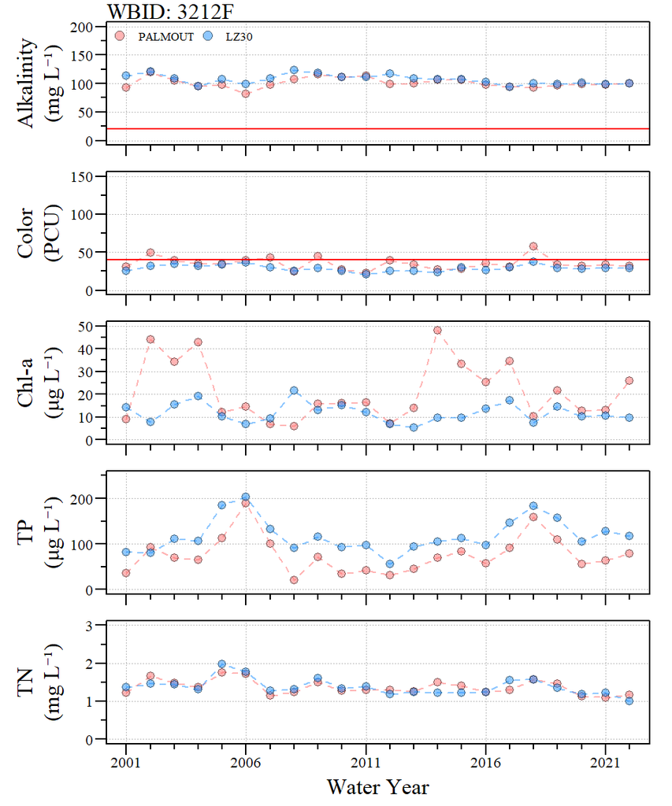

Annual Geometric Mean concentration for Alkalinity, Color, Chlorophyll, Total Phosphorus and Total Nitrogen .

Average annual geometric mean concentration across WBID3212F with annual exceedances identified by shaded area on the table.

| WBID | WY | Alkalinity (mg L⁻¹) | Color (PCU) | Chlorophyll-a (μg L⁻¹) | Total Phosphorus (mg L⁻¹) | Total Nitrogen (mg L⁻¹) |
| --- | --- | --- | --- | --- | --- | --- |
| 3212F | 2001 | 103 | 28 | 12 | 0.06 | 1.29 |
| 3212F | 2002 | 120 | 40 | 26 | 0.09 | 1.57 |
| 3212F | 2003 | 107 | 37 | 25 | 0.09 | 1.45 |
| 3212F | 2004 | 96 | 33 | 31 | 0.09 | 1.34 |
| 3212F | 2005 | 102 | 34 | 11 | 0.15 | 1.86 |
| 3212F | 2006 | 90 | 38 | 11 | 0.20 | 1.74 |
| 3212F | 2007 | 103 | 37 | 8 | 0.12 | 1.21 |
| 3212F | 2008 | 115 | 25 | 14 | 0.06 | 1.28 |
| 3212F | 2009 | 117 | 37 | 14 | 0.09 | 1.54 |
| 3212F | 2010 | 111 | 26 | 16 | 0.06 | 1.30 |
| 3212F | 2011 | 112 | 22 | 14 | 0.07 | 1.34 |
| 3212F | 2012 | 108 | 32 | 7 | 0.04 | 1.24 |
| 3212F | 2013 | 105 | 29 | 10 | 0.07 | 1.25 |
| 3212F | 2014 | 107 | 25 | 29 | 0.09 | 1.35 |
| 3212F | 2015 | 107 | 29 | 22 | 0.10 | 1.31 |
| 3212F | 2016 | 100 | 31 | 19 | 0.08 | 1.23 |
| 3212F | 2017 | 94 | 30 | 26 | 0.12 | 1.43 |
| 3212F | 2018 | 97 | 47 | 9 | 0.17 | 1.58 |
| 3212F | 2019 | 98 | 31 | 18 | 0.13 | 1.41 |
| 3212F | 2020 | 100 | 30 | 12 | 0.08 | 1.15 |
| 3212F | 2021 | 99 | 31 | 12 | 0.10 | 1.16 |
| 3212F | 2022 | 100 | 30 | 18 | 0.10 | 1.08 |

Includes Stations: PALMOUT, LZ30

##### 3212G

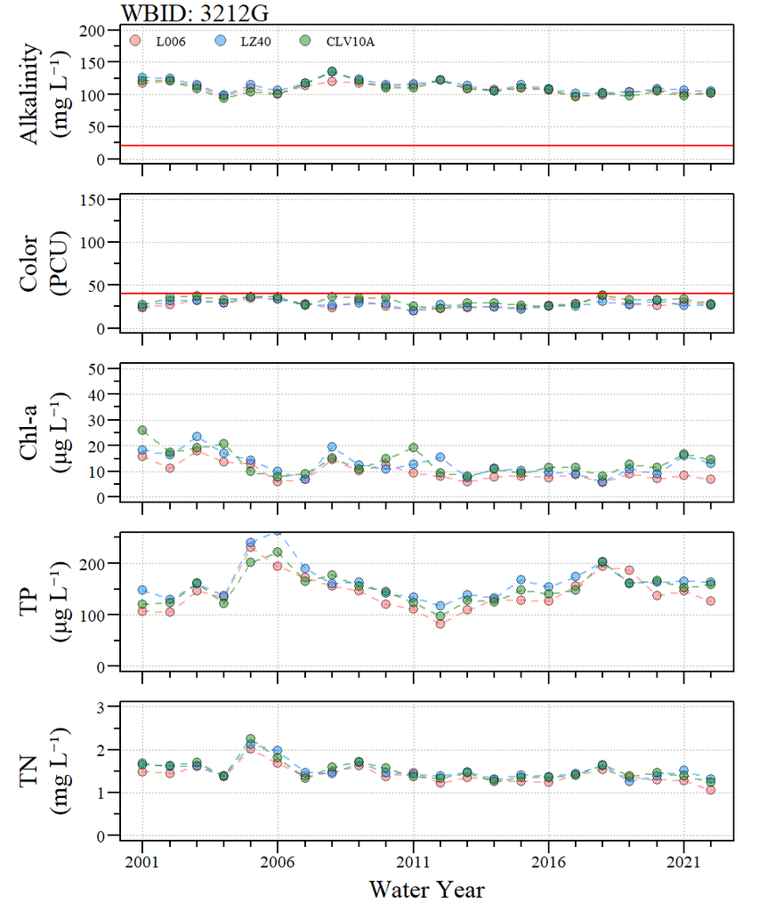

Annual Geometric Mean concentration for Alkalinity, Color, Chlorophyll, Total Phosphorus and Total Nitrogen .

Average annual geometric mean concentration across WBID3212G with annual exceedances identified by shaded area on the table.

| WBID | WY | Alkalinity (mg L⁻¹) | Color (PCU) | Chlorophyll-a (μg L⁻¹) | Total Phosphorus (mg L⁻¹) | Total Nitrogen (mg L⁻¹) |
| --- | --- | --- | --- | --- | --- | --- |
| 3212G | 2001 | 122 | 25 | 20 | 0.12 | 1.60 |
| 3212G | 2002 | 122 | 32 | 15 | 0.12 | 1.56 |
| 3212G | 2003 | 112 | 34 | 20 | 0.16 | 1.65 |
| 3212G | 2004 | 97 | 30 | 17 | 0.13 | 1.39 |
| 3212G | 2005 | 110 | 35 | 12 | 0.22 | 2.13 |
| 3212G | 2006 | 102 | 34 | 8 | 0.23 | 1.82 |
| 3212G | 2007 | 116 | 27 | 8 | 0.18 | 1.39 |
| 3212G | 2008 | 130 | 29 | 16 | 0.16 | 1.50 |
| 3212G | 2009 | 121 | 32 | 11 | 0.16 | 1.68 |
| 3212G | 2010 | 112 | 29 | 13 | 0.14 | 1.46 |
| 3212G | 2011 | 113 | 22 | 14 | 0.12 | 1.41 |
| 3212G | 2012 | 122 | 24 | 11 | 0.10 | 1.31 |
| 3212G | 2013 | 110 | 26 | 7 | 0.13 | 1.43 |
| 3212G | 2014 | 106 | 26 | 10 | 0.13 | 1.29 |
| 3212G | 2015 | 111 | 24 | 9 | 0.15 | 1.34 |
| 3212G | 2016 | 107 | 26 | 9 | 0.14 | 1.31 |
| 3212G | 2017 | 98 | 27 | 10 | 0.16 | 1.42 |
| 3212G | 2018 | 101 | 36 | 7 | 0.20 | 1.61 |
| 3212G | 2019 | 102 | 29 | 11 | 0.17 | 1.33 |
| 3212G | 2020 | 106 | 31 | 9 | 0.16 | 1.38 |
| 3212G | 2021 | 102 | 30 | 14 | 0.15 | 1.39 |
| 3212G | 2022 | 103 | 27 | 12 | 0.15 | 1.21 |

Includes Stations: L006, LZ40, CLV10A

##### 3212H

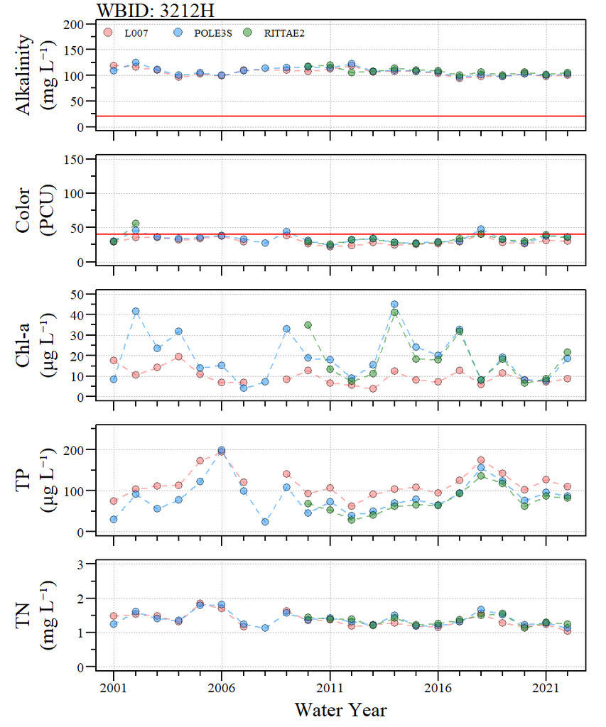

Annual Geometric Mean concentration for Alkalinity, Color, Chlorophyll, Total Phosphorus and Total Nitrogen .

Average annual geometric mean concentration across WBID3212H with annual exceedances identified by shaded area on the table.

| WBID | WY | Alkalinity (mg L⁻¹) | Color (PCU) | Chlorophyll-a (μg L⁻¹) | Total Phosphorus (mg L⁻¹) | Total Nitrogen (mg L⁻¹) |
| --- | --- | --- | --- | --- | --- | --- |
| 3212H | 2001 | 113 | 29 | 13 | 0.05 | 1.36 |
| 3212H | 2002 | 121 | 46 | 26 | 0.10 | 1.57 |
| 3212H | 2003 | 110 | 36 | 19 | 0.08 | 1.44 |
| 3212H | 2004 | 98 | 33 | 26 | 0.09 | 1.32 |
| 3212H | 2005 | 104 | 35 | 12 | 0.15 | 1.82 |
| 3212H | 2006 | 99 | 38 | 11 | 0.20 | 1.75 |
| 3212H | 2007 | 109 | 31 | 5 | 0.11 | 1.20 |
| 3212H | 2008 | 114 | 27 | 7 | 0.02 | 1.12 |
| 3212H | 2009 | 113 | 41 | 21 | 0.12 | 1.60 |
| 3212H | 2010 | 114 | 28 | 22 | 0.07 | 1.38 |
| 3212H | 2011 | 116 | 24 | 13 | 0.08 | 1.39 |
| 3212H | 2012 | 115 | 29 | 7 | 0.04 | 1.29 |
| 3212H | 2013 | 107 | 32 | 10 | 0.06 | 1.22 |
| 3212H | 2014 | 111 | 27 | 33 | 0.08 | 1.40 |
| 3212H | 2015 | 108 | 26 | 17 | 0.08 | 1.20 |
| 3212H | 2016 | 106 | 28 | 15 | 0.07 | 1.20 |
| 3212H | 2017 | 97 | 31 | 26 | 0.10 | 1.33 |
| 3212H | 2018 | 102 | 43 | 7 | 0.15 | 1.57 |
| 3212H | 2019 | 99 | 31 | 16 | 0.13 | 1.45 |
| 3212H | 2020 | 104 | 28 | 8 | 0.08 | 1.17 |
| 3212H | 2021 | 100 | 35 | 8 | 0.10 | 1.26 |
| 3212H | 2022 | 103 | 34 | 16 | 0.09 | 1.14 |

Includes Stations: L007, POLE3S, RITTAE2

##### 3212I

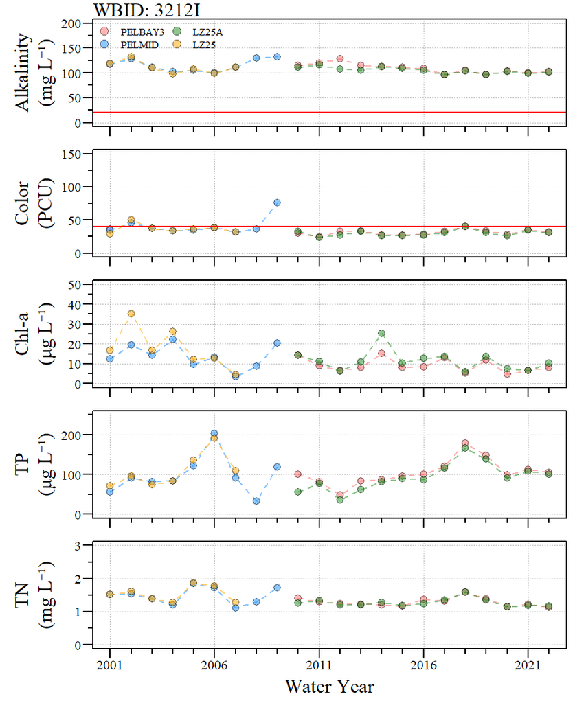

Annual Geometric Mean concentration for Alkalinity, Color, Chlorophyll, Total Phosphorus and Total Nitrogen .

Average annual geometric mean concentration across WBID3212I with annual exceedances identified by shaded area on the table.

| WBID | WY | Alkalinity (mg L⁻¹) | Color (PCU) | Chlorophyll-a (μg L⁻¹) | Total Phosphorus (mg L⁻¹) | Total Nitrogen (mg L⁻¹) |
| --- | --- | --- | --- | --- | --- | --- |
| 3212I | 2001 | 118 | 33 | 15 | 0.06 | 1.52 |
| 3212I | 2002 | 130 | 48 | 27 | 0.09 | 1.57 |
| 3212I | 2003 | 111 | 37 | 16 | 0.08 | 1.38 |
| 3212I | 2004 | 100 | 34 | 24 | 0.08 | 1.24 |
| 3212I | 2005 | 106 | 36 | 11 | 0.13 | 1.85 |
| 3212I | 2006 | 100 | 38 | 13 | 0.20 | 1.74 |
| 3212I | 2007 | 111 | 32 | 4 | 0.10 | 1.19 |
| 3212I | 2008 | 130 | 37 | 9 | 0.03 | 1.30 |
| 3212I | 2009 | 132 | 76 | 21 | 0.12 | 1.72 |
| 3212I | 2010 | 113 | 31 | 14 | 0.08 | 1.33 |
| 3212I | 2011 | 118 | 24 | 10 | 0.08 | 1.31 |
| 3212I | 2012 | 118 | 30 | 6 | 0.04 | 1.22 |
| 3212I | 2013 | 110 | 33 | 10 | 0.07 | 1.21 |
| 3212I | 2014 | 113 | 27 | 20 | 0.08 | 1.24 |
| 3212I | 2015 | 110 | 27 | 9 | 0.09 | 1.17 |
| 3212I | 2016 | 107 | 27 | 11 | 0.09 | 1.30 |
| 3212I | 2017 | 97 | 32 | 13 | 0.12 | 1.33 |
| 3212I | 2018 | 104 | 40 | 6 | 0.17 | 1.59 |
| 3212I | 2019 | 96 | 32 | 13 | 0.14 | 1.37 |
| 3212I | 2020 | 103 | 27 | 6 | 0.09 | 1.15 |
| 3212I | 2021 | 99 | 35 | 7 | 0.11 | 1.20 |
| 3212I | 2022 | 102 | 31 | 9 | 0.10 | 1.15 |

Includes Stations: PELBAY3, PELMID, LZ25A, LZ25